# AS6-2 資料案例：老忠實噴泉

第三組 黃柏勳 劉漢慈 王誠歆 李燦宇 張延瑋 王欣

2019-04-02 19:57:32

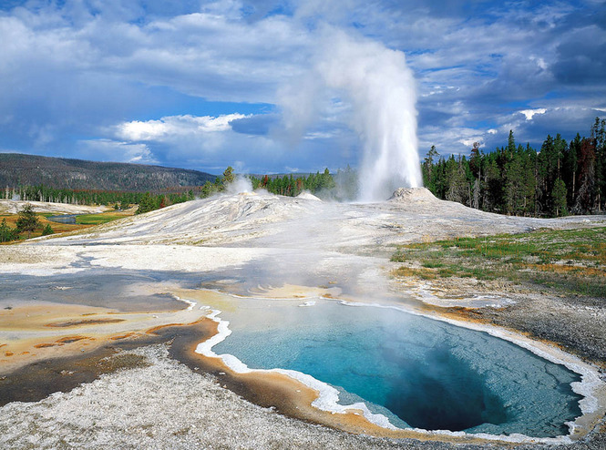

💡 **作業摘要：** 利用案例來加強統計概念與實務操作

- 利用老忠實噴泉的等待時間製作
  - 平滑曲線圖：機率密度函數(PDF)/累積機率密度函數(CDF)
  - 直方圖：機率密度函數(PDF)/累積機率密度函數(CDF)
- 資料處理(dplyr)與繪圖套件
  - `dplyr`
  - `tidyr`

💡 **資料檢視**

- R內建老忠實的資料中有兩個欄位
  - 噴發時間
  - 等待時間

```r
E = faithful$eruptions  # 簡化資料名稱
W = faithful$waiting
summary(W)
```

```
   Min. 1st Qu.  Median    Mean 3rd Qu.    Max.
   43.0    58.0    76.0    70.9    82.0    96.0
```

```r
length(W) # 資料共有272點
```

```
[1] 272
```

### 【A】製作老忠實噴泉等待時間的PDF/CDF

#### Frame

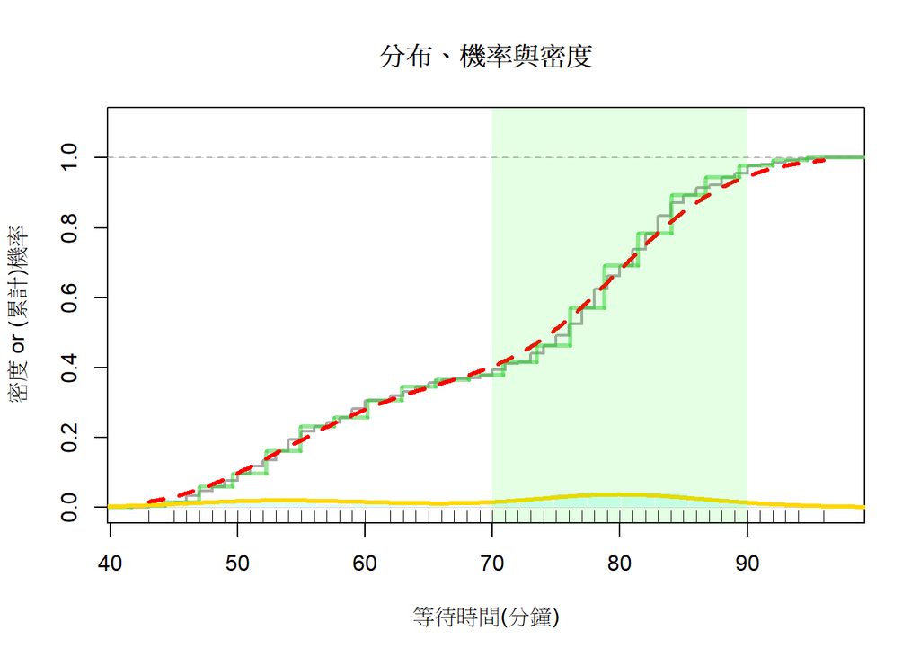

```r
### Basic settings
plot(0,0,xlim=c(42,97),ylim=c(0,1.1),xlab="等待時間(分鐘)",
     ylab="密度 or (累計)機率", main="分布、機率與密度")
abline(h=1, col='lightgray', lwd=0.25, lty=2)

### Empirical PDF
rug(W) #在有變數值的地方做標記 as pulse FUN

### Empirical CDF
plot(ecdf(W), cex=0, verticals=T, lwd=2, col='darkgray', add=T) #add是不要再畫一張新的圖

### Histogram PDF
Bins = 20                             # no. bins畫多少欄，調欄數的時候不要有一隻特高的情況會是比較好的
bx = seq(min(W), max(W), length=Bins+1) # break sequence
hist(W, col="#B3FFFF7F", border="white", ylim=c(0,1.1),
     freq=F,breaks=bx,  add=T)  #最後三個重要的參數：設定機率密度,並給予界線，添加圖上去
abline(h=0, col='lightgray', lwd=0.25)

### Histogram CDF
adj = (bx[2] - bx[1])/2
steps = stepfun(bx-adj, c(0, sapply(bx, function(b) mean(W <= b))))
plot(steps, cex=0, col='#33CC337F', lwd=3, lty=1, add=T)

### Smooth PDF
Adjust = 1    # bandwidth adjustment
DEN = density(W, adjust = Adjust)
lines(DEN, col='gold', lwd=3)

### Smooth CDF
PDF = approxfun(DEN$x, DEN$y, yleft=0, yright=0)
x = seq(min(W), max(W),0.1)
y = sapply(x, function(i) integrate(PDF, -Inf, i)$value) #從無限大積分到i來當成CDF再畫成線
lines(x, y, col='red', lwd=3, lty=2)

### Mark Range
x1 = 70; x2 = 90
rect(x1,-0.1,x2,1.2,col= rgb(0,1,0,alpha=0.1),border=NA)
```

- 因為真實的概率分布函数未知，故以真實資料繪圖。
- `ecdf()`函数中的e代表Empirical，意思是根據觀察值而來的，即具體描繪出來的CDF曲線根據各個數據點的總和而得到的。
- 平滑曲線的累積機率函數(CDF)
  - 設定頻寬並以資料點計算各隨機變數值下的機率密度
  - 以`approxfun`來製作相對應的機率密度函數
  - 把各點由負無窮大積分至該點，便可以計算出該點的累積機率

### 【B】程式模擬 v.s 理論分布

#### Binomial distribution

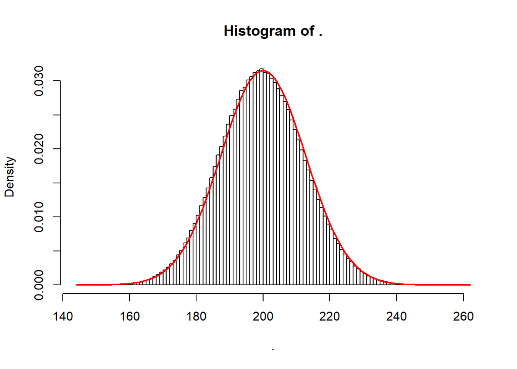

```r
rbinom(1000000, 1000, 0.2) %>% hist(breaks=100,freq=F)
curve(dnorm(x,mean=200,sd=sqrt(160)), col='red', lwd=2, add=T)
```

- 二項式分布
  - 以每次試驗設定為成功機率0.2且抽取1000樣本數，並執行1000000次的模擬結果
- 常態分布
  - 畫出以平均值200,變異數160的常態分佈曲線(理論分布)
- 由圖可以看出執行相當多次的二項式分布實驗下的抽樣結果會依據中央極限定理(CLT)收斂成常態分布。

⛲ 問題討論【A.選擇方法】：  
■ 我們為甚麼需要隨機變數？ 什麼時候我們需要用到隨機變數？  
透過隨機變數的結果我們可以觀察一個隨機試驗出現值的次數(機率密度)分布。  
當我們無法預知一個事件的結果可以透過隨機變數的模擬來預測結果，進一步產生策略觀點  
■ 隨機變數沒有固定的值，那我們要如何做計算呢？  
針對模擬的結果得到隨機變數值分布，透過適配一個恰當的機率分布可以去計算隨機變數的期望值及變異數  
■ 我們可以用直方圖或數值標記來估計噴發時間落在某一區間的機率嗎？  
可以透過直方圖計算某一區間的機率，機率 = 機率密度(density) × 欄寬(binwidth)  
數值標記的用意在於在有出現隨機變數值的位置標記，可以觀察密集程度來看出現頻率高低進而知道特定區間機率。  
■ 直方圖(histogram)也可以當作一種模型嗎？ 數值標記(rug)呢？  
兩者皆是模型，模型是將現實抽象化(Abstract of Reality)，使其好懂(好溝通)或好計算。  
直方圖呈現的是機率密度，可透過圖表概讀及公式計算出某段機率；另外數值標記透過圖像方式可以讓資料簡略呈現真實資料的分布狀況，讓決策者更好識別。  
■ 直方圖和平滑模型哪一個比較適合用來表示噴發時間的分布？ 為甚麼？  
平滑模型較適合，因為直方圖會因為欄寬設定不同而有較大的差異，而平滑模型直接表現各點下的機率密度更可以呈現噴發時間的分布  
■ 用數值標記來預測噴發時間會比用直方圖「準」嗎？ 「準」是什麼意思呢？  
會，因為直方圖是在某區間下的機率分布，但數值標記是在準確值上，不論是在敘述現在的資料或是未來預測值都會有比較好的表現，準的定義類似是“準確”，對於預測值的差距不要太大。

⛲ 問題討論【B.調整參數】：  
■ 你覺得最合適的直方圖欄數(support/binwidth)是？ 為甚麼？  
在調整平滑模型頻寬(bandwidth)為0.5的情況下，我覺得直方圖欄數(support/binwidth)設定在16的時候，彼此呈現的誤差較小。另外平滑模型頻寬0.5不會過於複雜(overfitting);直方圖欄數設定在16下，各區間的機率密度函數也不會過於極端。  
■ 最合適的平滑模型頻寬(bandwidth)呢？  
0.5  
■ 調高欄寬和頻寬會讓模型變複雜，還是變簡單呢？  
直方圖欄數增加(shiny app參數操作)，會讓模型變複雜；但題目調高欄“寬”及頻寬，都會讓模型變得簡單。  
■ 模型越複雜，它跟實際值之間的誤差是越大、還是越小？ 數值標記(rug)呢？  
越複雜是為了更貼合實際值，所以誤差會越來越小，數值標記就是表現真實值所以沒有誤差。  
■ 那麼，越複雜的模型就會越準，對嗎？  
不一定，因為不確定未來的資料是否相近於現在資料的表現，若過於複雜也會造成過度適配的問題反而會有更大的誤差。

⛲ 問題討論【C.建立模型、估計機率】：  
■ 從變數向量(D)求出機率密度曲線(DEN)  
DEN = density(D, adjust = input`$`B)  
■ 將機率密度曲線(DEN)轉換成機率密度函數(PDF)  
PDF = approxfun(DEN`$`x, DEN`$`y, yleft=0, yright=0)  
■ 對機率密度函數(PDF)做積分，算出機率(PROB)  
PROB = integrate(PDF, input`$`R[1], input`$`R[2])`$`value  
■ 將頻寬調整參數(adjust)設為1，算出「等待時間」落在80到90之間的機率  
0.26851  
■ 將頻寬調整參數設為0.5，算出等待時間落在80到90之間的機率  
0.28275  
■ 算出來的機率比較高的就是比較好的模型，對嗎？為甚麼？  
調整adjust從1到0.5，其實就是在調整平滑模型頻寬來影響機率函數，而調低頻寬使得模型變得複雜，才讓平滑曲線下的面積更多，機率變高。但仍然不能確定是否為比較好的模型。

**答案補充**

```r
D = faithful$waiting
Adjust= c(0.5,1)
probability = sapply(Adjust, function(x) {
    DEN = density(D, adjust = x)
    PDF = approxfun(DEN$x, DEN$y, yleft=0, yright=0)
    PROB = integrate(PDF, 80, 90)$value
  })
probability
```

```
[1] 0.28275 0.26851
```

⛲ 問題討論【D.預測與決策】：  
假設有一個賭局，你可以花30元選定一個連續60秒的時段，如果老忠實下一次的噴發時間落在你指定的區間，你就可以贏到100元；請你使用頻寬為0.5的平滑密度模型 …  
■ 決定要不要參加這個賭局  
要，因為期望值為17.7(元)，這是一個傾向於獲利的賭局。  
■ 如果你參加的話，你要把噴發時間設定在哪一個區間呢？  
設定在3.9-4.9(分鐘)  
■ 你設在這個區間的話，參加這個賭局的期望值是？  
17.66，是本次賭局的最大獲利報酬。  
假如賭場老闆從零開始把每10秒鐘設為一個區間，每個區間的賭金是五塊錢 …  
■ 你要怎麼押注，才能獲得最高的期望值呢？  
由於問題未指名確切的最大賭金，故本組設想兩種賭注方案：  
方案一：呈上題(賭金30元)，選擇前獲利最大的六個區間如下：  
⇒[`4.3333-4.5`]⁄[`4.5-4.6667`]⁄[`4.1666-4.3333`]⁄[`1.8333-2`]⁄[`4-4.1667`]⁄[`2-2.1667`]  
方案二：假設賭金無上限，故以賭金45元下選擇選擇前獲利最大的前九個區間(因有九個區間期望值為正或機率大於臨界機率0.05)  
除了上述六個區間的額外三個區間：  
⇒[`4.6667-4.8333`]⁄[`1.6667-1.8333`]⁄[`3.8333-4`]  
■ 你的賭金和期望值各是多少？  
方案一：選擇六個區間，總獲得最大獲利報酬為20.2944(元)  
方案二：選擇九個區間，總獲得最大獲利報酬為24.3380(元)  
將獲利的期望值和賭金的比值稱為「期望投資報酬率」 …  
■ 「最大期望投資報酬率」和「最大期望報酬」的投資策略是一樣的嗎？  
若以方案一來說，不論「最大期望投資報酬率」和「最大期望報酬」為目標，皆選擇投注十秒來加入賭局。  
若以方案二來說，以「最大期望投資報酬率」目標下，會選擇投注一分鐘來獲得較高的投注效率；而「最大期望報酬」目標下則選擇投注十秒來加入賭局。  
■ 你認為哪一個策略目標比較好呢？ 為什麼？  
以相同賭本來說，本組認為每一分錢需發揮最大價值，故以「最大期望投資報酬率」為目標；若不受賭本限制下，應把手中的錢發揮最大價值，故以「最大期望報酬」為目標。

**答案補充**

```r
E = faithful$eruptions
DEN = density(E, adjust = 0.5)
PDF = approxfun(DEN$x, DEN$y, yleft=0, yright=0)
prob = integrate(PDF,3.9,4.9)$value
```

*(1)選擇一分鐘的區間*

```r
x = seq(1, 6, .1)
px = sapply(11:length(x), # start by 11, so i-10 = 1
            function(i) integrate(PDF, x[i-10], x[i])$value)
payoff = 100 * px - 30
df = data.frame(x2=seq(2,6,.1), px, payoff)
df = df[order(-df$payoff),]  # order 是回傳位置，加負號是由大到小排，所以第30個是最大的報酬
df$cumsum =  cumsum(df$payoff)
df %>% head(14) #只顯示期望值為正的14個
```

```
    x2      px    payoff  cumsum
30 4.9 0.47660 17.660260  17.660
29 4.8 0.47554 17.553569  35.214
31 5.0 0.46073 16.073312  51.287
28 4.7 0.45825 15.824732  67.112
32 5.1 0.42968 12.967762  80.080
27 4.6 0.42744 12.743550  92.823
26 4.5 0.38703  8.702679 101.526
33 5.2 0.38697  8.696998 110.223
25 4.4 0.34123  4.122736 114.346
34 5.3 0.33626  3.625890 117.971
6  2.5 0.32120  2.119882 120.091
7  2.6 0.31890  1.890142 121.982
5  2.4 0.31043  1.042980 123.024
8  2.7 0.30071  0.071161 123.096
```

*(2)選擇十秒鐘的區間*

```r
x = seq(1, 6, 1/6)
px = sapply(2:length(x), # start by 2, so i-1 = 1
            function(i) integrate(PDF, x[i-1], x[i])$value)
payoff = 100 * px - 5
df = data.frame(x2=x[-1], px, payoff)
df = df[order(-df$payoff),]  # order 是回傳位置，加負號是由大到小排，所以第21個是最大的報酬
df$cumsum =  cumsum(df$payoff)
df %>% head(9)  #只顯示期望值為正的9個
```

```
       x2       px  payoff  cumsum
21 4.5000 0.095766 4.57661  4.5766
22 4.6667 0.089384 3.93845  8.5151
20 4.3333 0.089324 3.93240 12.4475
6  2.0000 0.082258 3.22576 15.6732
19 4.1667 0.076536 2.65357 18.3268
7  2.1667 0.069676 1.96764 20.2944
23 4.8333 0.068427 1.84265 22.1371
5  1.8333 0.063668 1.36677 23.5038
18 4.0000 0.058341 0.83413 24.3380
```

*方案一比較*

|  | **一分鐘** | **十秒(方案一)** |
| --- | --- | --- |
| **最大期望投資報酬率** | `17.66/30=0.5887` | **`20.2944/30=0.6765`** |
| **最大期望報酬** | `17.66` | **`20.2944`** |

*方案二比較*

|  | **一分鐘** | **十秒(方案二)** |
| --- | --- | --- |
| **最大期望投資報酬率** | **`17.66/30=0.5887`** | `24.3380/45=0.5408` |
| **最大期望報酬** | `17.66` | **`24.3380`** |

- 本組發現若時間區間切割較小，所獲得的總期望報酬會比較大。